# Confirmatory 1B Analysis Markdown

# PREPARATION

## Load Packages

```r
library(tidyverse)
library(janitor)
library(grid)
library(cowplot)
library(httr)
library(extrafont)
library(here)
library(ggeasy)
library(rstatix)
library(apa)
library(ez)
library(afex)
library(papaja)
```

## Read in data

```r
options(scipen=999) # remove scientific notation

data1B <- read_csv(here("data_files", "scored_master_dataset_1B.csv"))
```

## First factor: Subfield

```r
# first, let's collapse the subfields into 4 main groups: developmental, cognition, social and 'other'
subfield_groups <- data1B %>%
  mutate(subfield_groups = case_when(subfield == "Behavioural Neuroscience" ~ "Other",
                                     subfield == "Cognitive Neuroscience" ~ "Other",
                                     subfield == "Health Psychology" ~ "Other",
                                     subfield == "Perception" ~ "Other",
                                     subfield == "Developmental Psychology" ~ "Development",
                                     subfield == "Social Psychology" ~  "Social",
                                     TRUE ~ as.character(subfield))) %>%
  relocate(subfield_groups, .after = subfield)

# we can now delete the original subfield column
subfield_groups <- subfield_groups %>%
  select(-subfield)
```

## Second factor: Time

```r
dates <- subfield_groups %>%
  mutate(time_period = case_when(
    str_detect(article_id_number, "2019-30-7|2019-30-8|2019-30-9|2019-30-10|2019-30-11|2019-30-12") ~ "2nd half 2019",
    str_detect(article_id_number, "2020-31-1|2020-31-2|2020-31-3|2020-31-4|2020-31-5|2020-31-6") ~ "1st half 2020",
    str_detect(article_id_number, "2020-31-7|2020-31-8|2020-31-9|2020-31-10|2020-31-11|2020-31-12") ~ "2nd half 2020")) %>%
  relocate(time_period, .after = article_id_number)
```

## Selecting only relevant data

```r
final1B <- dates %>%
  select(article_id_number, subfield_groups, time_period, total_data_score, total_materials_score)

# make sure subfield and timeperiod are factors

final1B$subfield_groups <- as.factor(final1B$subfield_groups)
final1B$time_period <- fct_relevel(final1B$time_period, c("2nd half 2019", "1st half 2020","2nd half 2020"))

# check data types

glimpse(final1B)
```

```
## Rows: 193
## Columns: 5
## $ article_id_number     <chr> "2019-30-12-1780", "2020-31-5-518", "2020-31-12-…
## $ subfield_groups       <fct> Development, Social, Social, Development, Cognit…
## $ time_period           <fct> 2nd half 2019, 1st half 2020, 1st half 2020, 2nd…
## $ total_data_score      <dbl> 0, 18, 1, 19, 1, 19, 19, 1, 19, 12, 0, 14, 24, 2…
## $ total_materials_score <dbl> 0, 0, 1, 0, 0, 6, 19, 1, 14, 14, 0, 14, 12, 19, …
```

# DATA ANOVA Analysis

```r
# We decided to use Type II ANOVA tests because this appears to be the more conservative test out of Type I, II and III tests, and is most appropriate for our findings

data_ANOVA <- final1B %>%
  anova_test(total_data_score ~ subfield_groups * time_period)
```

```
## Coefficient covariances computed by hccm()
```

```r
data_ANOVA
```

```
## ANOVA Table (type II tests)
##
##                        Effect DFn DFd     F     p p<.05   ges
## 1             subfield_groups   3 181 3.335 0.021     * 0.052
## 2                 time_period   2 181 3.476 0.033     * 0.037
## 3 subfield_groups:time_period   6 181 1.101 0.364       0.035
```

Our two-way between-subjects ANOVA generated a significant main effect of subfield, F(3, 181) = 3.335, p = 0.021, ges = 0.052, and time period, F(2, 181) = 3.476, p = 0.033, ges = 0.037. However, the interaction between subfield and time period, F(6, 181) = 1.101, ges = 0.035, was not statistically significant.

```r
# Alternatively we can use the papaja package to print the stats:

data_aov <- aov_ez(
  data = final1B, dv = "total_data_score",
  id = "article_id_number",
  between = c("time_period", "subfield_groups"),
  type = "2"
)
```

```
## Contrasts set to contr.sum for the following variables: time_period, subfield_groups
```

```r
data_aov$anova_table
```

```
## Anova Table (Type 2 tests)
##
## Response: total_data_score
##                             num Df den Df    MSE     F      ges  Pr(>F)
## time_period                      2    181 71.018 3.476 0.036989 0.03301 *
## subfield_groups                  3    181 71.018 3.335 0.052381 0.02067 *
## time_period:subfield_groups      6    181 71.018 1.101 0.035212 0.36352
## ---
## Signif. codes:  0 '***' 0.001 '**' 0.01 '*' 0.05 '.' 0.1 ' ' 1
```

```r
data_apa <- apa_print(data_aov)

apa_table(data_apa$table,
          caption = "Between-subjects ANOVA for Open Data Scores",
          note = "This table was created with apa_table().")
```

(#tab:unnamed-chunk-7)

*Between-subjects ANOVA for Open Data Scores*

| Effect | $F$ | $\mathit{df}_1$ | $\mathit{df}_2$ | $\mathit{MSE}$ | $p$ | $\hat{\eta}^2_G$ |
| --- | --- | --- | --- | --- | --- | --- |
| Time period | 3.48 | 2 | 181 | 71.02 | .033 | .037 |
| Subfield groups | 3.33 | 3 | 181 | 71.02 | .021 | .052 |
| Time period $\times$ Subfield groups | 1.10 | 6 | 181 | 71.02 | .364 | .035 |

*Note.* This table was created with apa_table().

Our two-way between-subjects ANOVA generated a significant main effect of time period, $F(2, 181) = 3.48$, $\mathit{MSE} = 71.02$, $p = .033$, $\hat{\eta}^2_G = .037$, and a significant main effect of subfield, $F(3, 181) = 3.33$, $\mathit{MSE} = 71.02$, $p = .021$, $\hat{\eta}^2_G = .052$. However, the interaction between time period and subfield, $F(6, 181) = 1.10$, $\mathit{MSE} = 71.02$, $p = .364$, $\hat{\eta}^2_G = .035$, was not statistically significant.

# MATERIALS ANOVA Analysis

```r
materials_ANOVA <- final1B %>%
  anova_test(total_materials_score ~ subfield_groups * time_period)
```

```
## Coefficient covariances computed by hccm()
```

```r
materials_ANOVA
```

```
## ANOVA Table (type II tests)
##
##                        Effect DFn DFd     F     p p<.05   ges
## 1             subfield_groups   3 181 5.236 0.002     * 0.080
## 2                 time_period   2 181 0.366 0.694       0.004
## 3 subfield_groups:time_period   6 181 0.481 0.822       0.016
```

Our two-way between-subjects ANOVA generated a significant main effect of subfield, F(3, 181) = 5.236, p = 0.002, ges = 0.08. However, the main effect of time period, F(2, 181) = 0.366, p = 0.694, ges = 0.004, and the interaction between subfield and time period, F(6, 181) = 0.481, ges = 0.016, was not statistically significant.

```r
# Alternatively we can use the papaja package to print the stats:

materials_aov <- aov_ez(
  data = final1B, dv = "total_materials_score",
  id = "article_id_number",
  between = c("time_period", "subfield_groups"),
  type = "2"
)
```

```
## Contrasts set to contr.sum for the following variables: time_period, subfield_groups
```

```r
materials_aov$anova_table
```

```
## Anova Table (Type 2 tests)
##
## Response: total_materials_score
##                             num Df den Df    MSE      F      ges  Pr(>F)
## time_period                      2    181 53.872 0.3657 0.004025 0.69419
## subfield_groups                  3    181 53.872 5.2357 0.079851 0.00173 **
## time_period:subfield_groups      6    181 53.872 0.4813 0.015704 0.82171
## ---
## Signif. codes:  0 '***' 0.001 '**' 0.01 '*' 0.05 '.' 0.1 ' ' 1
```

```r
materials_apa <- apa_print(materials_aov)

apa_table(materials_apa$table,
          caption = "Between-subjects ANOVA for Open Materials Scores",
          note = "This table was created with apa_table().")
```

(#tab:unnamed-chunk-9)

*Between-subjects ANOVA for Open Materials Scores*

| Effect | $F$ | $\mathit{df}_1$ | $\mathit{df}_2$ | $\mathit{MSE}$ | $p$ | $\hat{\eta}^2_G$ |
| --- | --- | --- | --- | --- | --- | --- |
| Time period | 0.37 | 2 | 181 | 53.87 | .694 | .004 |
| Subfield groups | 5.24 | 3 | 181 | 53.87 | .002 | .080 |
| Time period $\times$ Subfield groups | 0.48 | 6 | 181 | 53.87 | .822 | .016 |

*Note.* This table was created with apa_table().

Our two-way between-subjects ANOVA generated a significant main effect of subfield, $F(3, 181) = 5.24$, $\mathit{MSE} = 53.87$, $p = .002$, $\hat{\eta}^2_G = .080$, however the main effect of time period, $F(2, 181) = 0.37$, $\mathit{MSE} = 53.87$, $p = .694$, $\hat{\eta}^2_G = .004$, and the interaction between time period and subfield, $F(6, 181) = 0.48$, $\mathit{MSE} = 53.87$, $p = .822$, $\hat{\eta}^2_G = .016$, were not statistically significant.

# PLOTS

## DATA

### Subfield x Data Score

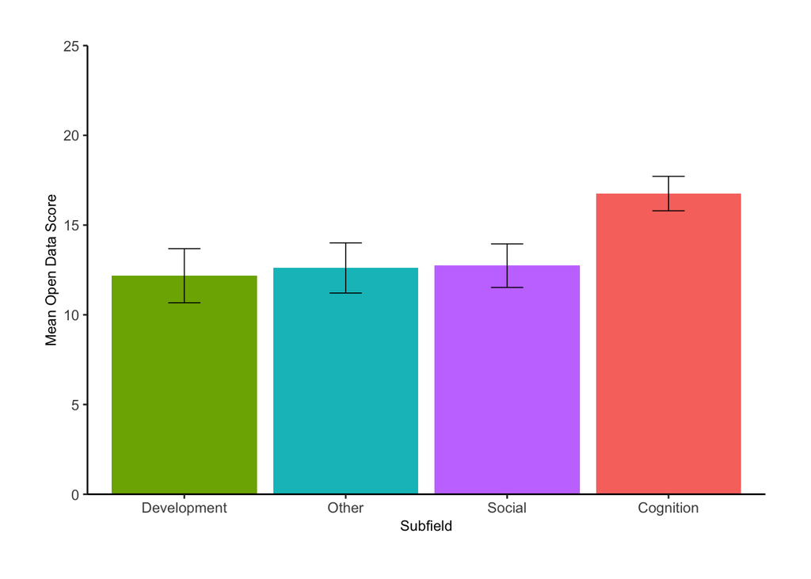

```r
data_subfield_descriptives <- final1B %>%
  group_by(subfield_groups) %>%
  summarise(mean_data_score = mean(total_data_score, na.rm = TRUE),
            SD = sd(total_data_score, na.rm = TRUE),
            N = n(),
            stderr = SD/sqrt(N))

# let's plot this

data_subfield_descriptives %>%
  ggplot(aes(x = reorder(subfield_groups, mean_data_score), y = mean_data_score, fill = subfield_groups)) +
  geom_col() +
  geom_errorbar(aes(ymin = mean_data_score - stderr, ymax = mean_data_score + stderr), # specifying what the standard error is
                size=.3, # thinner lines
                width=.2) + # narrower bars
  theme_classic() + # white background
  scale_y_continuous(limits = c(0,25), expand = c(0,0)) + # getting the bars to start at the bottom of the graph
  easy_remove_legend() +
  easy_all_text_size(size = 9) + # change the size of the text
  easy_labs(x = "Subfield", y = "Mean Open Data Score") + # change the x and y labels
  theme(plot.margin=unit(c(1,1,1,1),"cm")) # more white space
```

### Time Period x Data Score

```r
data_timeperiod_descriptives <- final1B %>%
  group_by(time_period) %>%
  summarise(mean_data_score = mean(total_data_score, na.rm = TRUE),
            SD = sd(total_data_score, na.rm = TRUE),
            N = n(),
            stderr = SD/sqrt(N))

data_timeperiod_descriptives$time_period <- fct_relevel(data_timeperiod_descriptives$time_period, c("2nd half 2019", "1st half 2020", "2nd half 2020"))

levels(data_timeperiod_descriptives$time_period)
```

```
## [1] "2nd half 2019" "1st half 2020" "2nd half 2020"
```

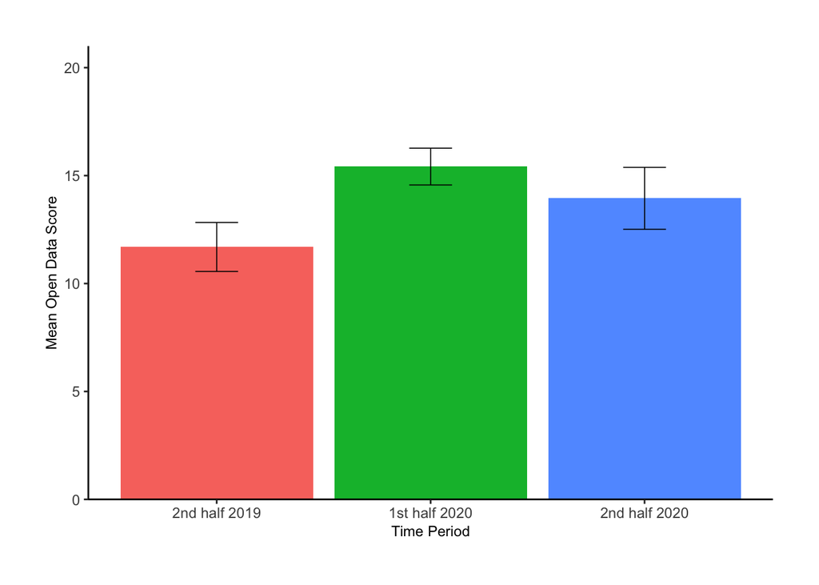

```r
# let's plot this

data_timeperiod_descriptives %>%
  ggplot(aes(x = time_period, y = mean_data_score, fill = time_period)) +
  geom_col() +
  geom_errorbar(aes(ymin = mean_data_score - stderr, ymax = mean_data_score + stderr), # specifying what the standard error is
                size=.3, # thinner lines
                width=.2) + # narrower bars
  theme_classic() + # white background
  scale_y_continuous(limits = c(0,21), expand = c(0,0)) + # getting the bars to start at the bottom of the graph
  easy_remove_legend() +
  easy_all_text_size(size = 9) + # change the size of the text
  easy_labs(x = "Time Period", y = "Mean Open Data Score") + # change the x and y labels
  theme(plot.margin=unit(c(1,1,1,1),"cm")) # more white space
```

### Interaction between time and subfield - Data scores

```r
data_subfieldtime_descriptives <- final1B %>%
  group_by(subfield_groups, time_period) %>%
  summarise(mean_data_score = mean(total_data_score, na.rm = TRUE),
            SD = sd(total_data_score, na.rm = TRUE),
            N = n(),
            stderr = SD/sqrt(N))
```

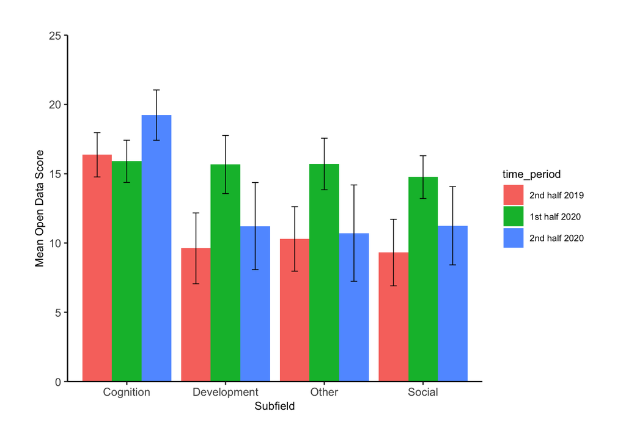

```r
data_subfieldtime_descriptives $time_period <- fct_relevel(data_subfieldtime_descriptives $time_period, c("2nd half 2019", "1st half 2020", "2nd half 2020"))

data_subfieldtime_descriptives  %>%
  ggplot(aes(x = subfield_groups, y = mean_data_score, fill = time_period)) +
  geom_col(position = "dodge") +
  geom_errorbar(aes(ymin = mean_data_score - stderr, ymax = mean_data_score + stderr), # specifying what the standard error is
                size=.3, # thinner lines
                width=.2, # narrower bars
                position=position_dodge(.9)) +
  theme_classic() + # white background
  scale_y_continuous(limits = c(0,25), expand = c(0,0)) + # getting the bars to start at the bottom of the graph
  easy_all_text_size(size = 9) + # change the size of the text
  easy_labs(x = "Subfield", y = "Mean Open Data Score") + # change the x and y labels
  theme(plot.margin=unit(c(1,1,1,1),"cm"))  # more white space
```

## MATERIALS

### Subfield x Materials Score

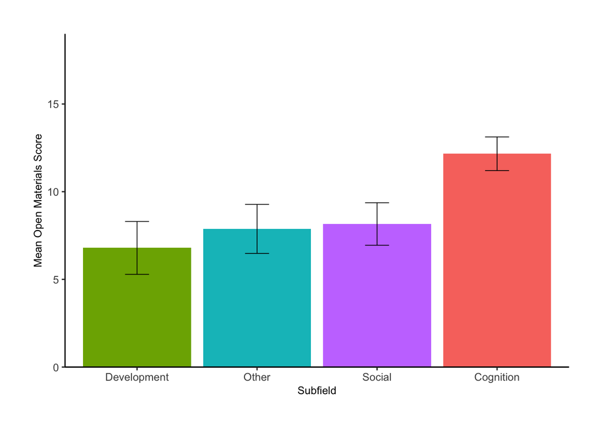

```r
materials_subfield_descriptives <- final1B %>%
  group_by(subfield_groups) %>%
  summarise(mean_materials_score = mean(total_materials_score, na.rm = TRUE),
            SD = sd(total_data_score, na.rm = TRUE),
            N = n(),
            stderr = SD/sqrt(N))

# let's plot this

materials_subfield_descriptives %>%
  ggplot(aes(x = reorder(subfield_groups, mean_materials_score), y = mean_materials_score, fill = subfield_groups)) +
  geom_col() +
  geom_errorbar(aes(ymin = mean_materials_score - stderr, ymax = mean_materials_score + stderr), # specifying what the standard error is
                size=.3, # thinner lines
                width=.2) + # narrower bars
  theme_classic() + # white background
  scale_y_continuous(limits = c(0,19), expand = c(0,0)) + # getting the bars to start at the bottom of the graph
  easy_remove_legend() +
  easy_all_text_size(size = 9) + # change the size of the text
  easy_labs(x = "Subfield", y = "Mean Open Materials Score") + # change the x and y labels
  theme(plot.margin=unit(c(1,1,1,1),"cm")) # more white space
```

### Time Period x Materials Score

```r
materials_timeperiod_descriptives <- final1B %>%
  group_by(time_period) %>%
  summarise(mean_materials_score = mean(total_materials_score, na.rm = TRUE),
            SD = sd(total_materials_score, na.rm = TRUE),
            N = n(),
            stderr = SD/sqrt(N))

materials_timeperiod_descriptives$time_period <- fct_relevel(materials_timeperiod_descriptives$time_period, c("2nd half 2019", "1st half 2020", "2nd half 2020"))

levels(materials_timeperiod_descriptives$time_period)
```

```
## [1] "2nd half 2019" "1st half 2020" "2nd half 2020"
```

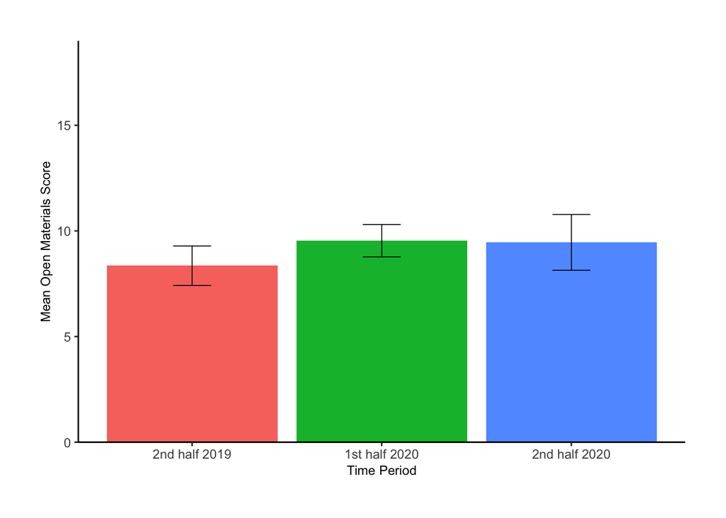

```r
# let's plot this

materials_timeperiod_descriptives %>%
  ggplot(aes(x = time_period, y = mean_materials_score, fill = time_period)) +
  geom_col() +
  geom_errorbar(aes(ymin = mean_materials_score - stderr, ymax = mean_materials_score + stderr), # specifying what the standard error is
                size=.3, # thinner lines
                width=.2) + # narrower bars
  theme_classic() + # white background
  scale_y_continuous(limits = c(0,19), expand = c(0,0)) + # getting the bars to start at the bottom of the graph
  easy_remove_legend() +
  easy_all_text_size(size = 9) + # change the size of the text
  easy_labs(x = "Time Period", y = "Mean Open Materials Score") + # change the x and y labels
  theme(plot.margin=unit(c(1,1,1,1),"cm")) # more white space
```

### Interaction between time and subfield - Materials Score

```r
materials_subfieldtime_descriptives <- final1B %>%
  group_by(subfield_groups, time_period) %>%
  summarise(mean_materials_score = mean(total_materials_score, na.rm = TRUE),
            SD = sd(total_materials_score, na.rm = TRUE),
            N = n(),
            stderr = SD/sqrt(N))
```

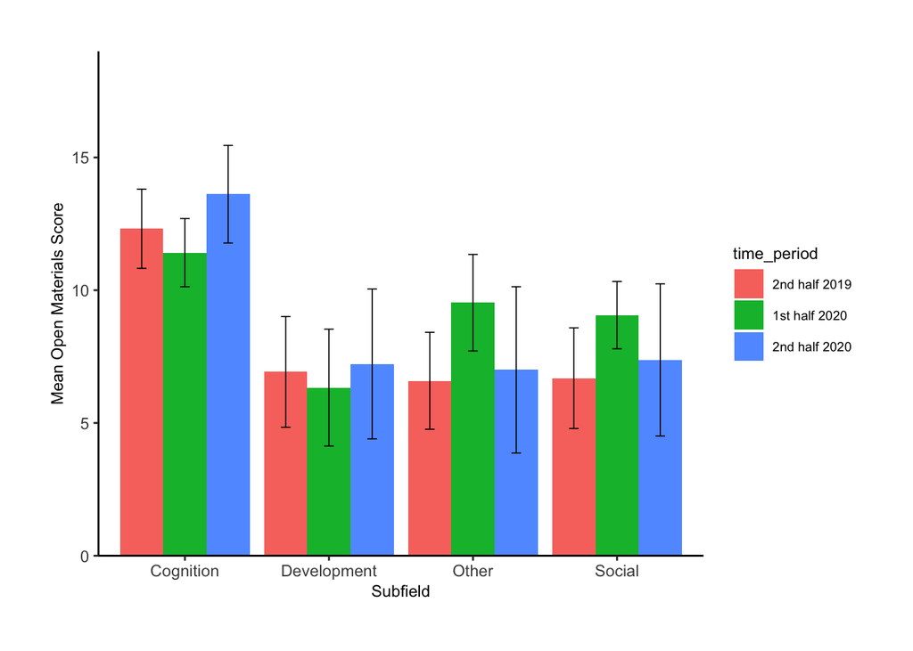

```r
materials_subfieldtime_descriptives $time_period <- fct_relevel(materials_subfieldtime_descriptives $time_period, c("2nd half 2019", "1st half 2020", "2nd half 2020"))

materials_subfieldtime_descriptives  %>%
  ggplot(aes(x = subfield_groups, y = mean_materials_score, fill = time_period)) +
  geom_col(position = "dodge") +
  geom_errorbar(aes(ymin = mean_materials_score - stderr, ymax = mean_materials_score + stderr), # specifying what the standard error is
                size=.3, # thinner lines
                width=.2, # narrower bars
                position=position_dodge(.9)) +
  theme_classic() + # white background
  scale_y_continuous(limits = c(0,19), expand = c(0,0)) + # getting the bars to start at the bottom of the graph
  easy_all_text_size(size = 9) + # change the size of the text
  easy_labs(x = "Subfield", y = "Mean Open Materials Score") + # change the x and y labels
  theme(plot.margin=unit(c(1,1,1,1),"cm"))  # more white space
```

# SUBFIELD T-TESTS

## DATA

### Development vs. Cognition

```r
devcog_data <- final1B %>%
  filter(subfield_groups %in% c("Development", "Cognition"))

pairwise_t_test(devcog_data, total_data_score ~ subfield_groups)
```

```
## # A tibble: 1 × 9
##   .y.              group1    group2    n1    n2      p p.signif  p.adj p.adj.signif
## * <chr>            <chr>     <chr>  <int> <int>  <dbl> <chr>     <dbl> <chr>
## 1 total_data_score Cognition Devel…    61    34 0.0087 **       0.0087 **
```

```r
devcog_data_output <- apa_print(t.test(total_data_score ~ subfield_groups, data = devcog_data))
```

A pairwise t-test showed that articles published in the subfield of Cognition generated significantly higher average Open Data Scores than articles in Developmental Psychology, $t(59.76) = 2.56$, $p = .013$.

### Development vs. Social

```r
devsocial_data <- final1B %>%
  filter(subfield_groups %in% c("Development", "Social"))

pairwise_t_test(devsocial_data, total_data_score ~ subfield_groups)
```

```
## # A tibble: 1 × 9
##   .y.              group1      group2    n1    n2     p p.signif p.adj p.adj.signif
## * <chr>            <chr>       <chr>  <int> <int> <dbl> <chr>    <dbl> <chr>
## 1 total_data_score Development Social    34    57 0.775 ns       0.775 ns
```

```r
devsocial_data_output <- apa_print(t.test(total_data_score ~ subfield_groups, data = devsocial_data))
```

A pairwise t-test showed that articles published in the subfield of Social Psychology did not generate significantly different Open Data Scores, on average, than articles in Developmental Psychology, $t(71.79) = -0.29$, $p = .773$.

### Development vs. Other

```r
devother_data <- final1B %>%
  filter(subfield_groups %in% c("Development", "Other"))

pairwise_t_test(devother_data, total_data_score ~ subfield_groups)
```

```
## # A tibble: 1 × 9
##   .y.              group1      group2    n1    n2     p p.signif p.adj p.adj.signif
## * <chr>            <chr>       <chr>  <int> <int> <dbl> <chr>    <dbl> <chr>
## 1 total_data_score Development Other     34    41 0.834 ns       0.834 ns
```

```r
devother_data_output <- apa_print(t.test(total_data_score ~ subfield_groups, data = devother_data))
```

A pairwise t-test showed that articles published in the ‘Other’ subfield did not generate significantly different Open Data Scores, on average, than articles in Developmental Psychology, $t(70.89) = -0.21$, $p = .834$.

## MATERIAL

### Developmental vs. Cognition

```r
devcog_materials <- final1B %>%
  filter(subfield_groups %in% c("Development", "Cognition"))

pairwise_t_test(devcog_materials, total_materials_score ~ subfield_groups)
```

```
## # A tibble: 1 × 9
##   .y.                   group1 group2    n1    n2       p p.signif   p.adj p.adj.signif
## * <chr>                 <chr>  <chr>  <int> <int>   <dbl> <chr>      <dbl> <chr>
## 1 total_materials_score Cogni… Devel…    61    34 5.47e-4 ***      5.47e-4 ***
```

```r
devcog_materials_output <- apa_print(t.test(total_materials_score ~ subfield_groups, data = devcog_materials))
```

### Developmental vs. Social

```r
devsocial_materials <- final1B %>%
  filter(subfield_groups %in% c("Development", "Social"))

pairwise_t_test(devsocial_materials, total_materials_score ~ subfield_groups)
```

```
## # A tibble: 1 × 9
##   .y.                   group1 group2    n1    n2     p p.signif p.adj p.adj.signif
## * <chr>                 <chr>  <chr>  <int> <int> <dbl> <chr>    <dbl> <chr>
## 1 total_materials_score Devel… Social    34    57 0.402 ns       0.402 ns
```

```r
devsocial_materials_output <- apa_print(t.test(total_materials_score ~ subfield_groups, data = devsocial_materials))
```

### Developmental vs. Other

```r
devother_materials <- final1B %>%
  filter(subfield_groups %in% c("Development", "Other"))

pairwise_t_test(devother_materials, total_materials_score ~ subfield_groups)
```

```
## # A tibble: 1 × 9
##   .y.                   group1 group2    n1    n2     p p.signif p.adj p.adj.signif
## * <chr>                 <chr>  <chr>  <int> <int> <dbl> <chr>    <dbl> <chr>
## 1 total_materials_score Devel… Other     34    41 0.539 ns       0.539 ns
```

```r
devother_materials_output <- apa_print(t.test(total_materials_score ~ subfield_groups, data = devother_materials))
```